# Preliminary Analysis - Effect of Economic Crisis

```r
summary(trend.preds)
```

```
##
## Forecast method: ARIMA(0,1,0) with drift
##
## Model Information:
## Series: trendsts.usabc
## ARIMA(0,1,0) with drift
##
## Coefficients:
##         drift
##       -0.3463
## s.e.   0.1083
##
## sigma^2 estimated as 0.07817:  log likelihood=-3.47
## AIC=10.94   AICc=11.86   BIC=12.49
##
## Error measures:
##                       ME      RMSE       MAE        MPE     MAPE      MASE
## Training set 0.001727376 0.3264833 0.2041199 0.05266215 1.477677 0.5825066
##                  ACF1
## Training set 0.267535
##
## Forecasts:
##      Point Forecast     Lo 80    Hi 80     Lo 95    Hi 95
## 2008      12.768023 12.409722 13.12632 12.220049 13.31600
## 2009      12.421735 11.915021 12.92845 11.646783 13.19669
## 2010      12.075448 11.454852 12.69604 11.126329 13.02457
## 2011      11.729160 11.012558 12.44576 10.633212 12.82511
## 2012      11.382873 10.581688 12.18406 10.157566 12.60818
## 2013      11.036585 10.158931 11.91424  9.694329 12.37884
## 2014      10.690298  9.742323 11.63827  9.240495 12.14010
## 2015      10.344010  9.330582 11.35744  8.794106 11.89391
## 2016       9.997723  8.922820 11.07263  8.353801 11.64164
## 2017       9.651435  8.518388 10.78448  7.918590 11.38428
## 2018       9.305148  8.116798 10.49350  7.487724 11.12257
## 2019       8.958860  7.717670 10.20005  7.060623 10.85710
```

```r
par(mfrow=c(1,2))
trends.usa <-region_data %>% select(Year,Trade,Country.Code) %>% filter(Country.Code == "NAC")
trendsts.usa <- ts(as.vector(trends.usa$Trade),start = c(1991,1), end = c(2014), frequency = 1)

trends.usabc <- region_data  %>% select(Year,Trade,Country.Code) %>% filter(Country.Code == "NAC" & Year >=1991 & Year<=2007)
trendsts.usabc <- ts(as.vector(trends.usabc$Trade),start = c(1991,1), end = c(2007), frequency = 1)

plot(trendsts.usa, ylim = c(25,38), xlim = c(2000,2009))


trends.arimausa<- auto.arima(trendsts.usabc)
trends.arimausa
```

```
## Series: trendsts.usabc
## ARIMA(0,1,0) with drift
##
## Coefficients:
##        drift
##       0.5637
## s.e.  0.2644
##
## sigma^2 estimated as 1.193:  log likelihood=-23.6
## AIC=51.2   AICc=52.13   BIC=52.75
```

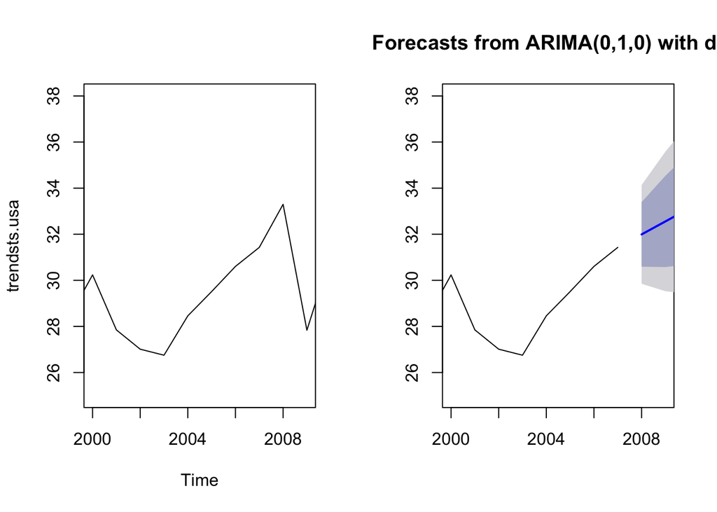

```r
trend.preds<-forecast.Arima(trends.arimausa,h=12)
plot.forecast(trend.preds, ylim = c(25,38), xlim = c(2000,2009))
```

```r
summary(trend.preds)
```

```
##
## Forecast method: ARIMA(0,1,0) with drift
##
## Model Information:
## Series: trendsts.usabc
## ARIMA(0,1,0) with drift
##
## Coefficients:
##        drift
##       0.5637
## s.e.  0.2644
##
## sigma^2 estimated as 1.193:  log likelihood=-23.6
## AIC=51.2   AICc=52.13   BIC=52.75
##
## Error measures:
##                       ME     RMSE       MAE         MPE     MAPE      MASE
## Training set 0.001285059 1.026187 0.7395763 -0.03259337 2.664621 0.7231065
##                    ACF1
## Training set 0.09761139
##
## Forecasts:
##      Point Forecast    Lo 80    Hi 80    Lo 95    Hi 95
## 2008       31.99241 30.59237 33.39245 29.85123 34.13359
## 2009       32.55610 30.57614 34.53606 29.52801 35.58419
## 2010       33.11979 30.69484 35.54473 29.41115 36.82842
## 2011       33.68348 30.88339 36.48356 29.40111 37.96584
## 2012       34.24716 31.11657 37.37776 29.45934 39.03499
## 2013       34.81085 31.38146 38.24025 29.56605 40.05566
## 2014       35.37454 31.67038 39.07871 29.70951 41.03958
## 2015       35.93823 31.97831 39.89815 29.88205 41.99441
## 2016       36.50192 32.30179 40.70205 30.07837 42.92546
## 2017       37.06561 32.63828 41.49293 30.29460 43.83662
## 2018       37.62930 32.98588 42.27271 30.52780 44.73079
## 2019       38.19298 33.34309 43.04288 30.77571 45.61025
```

```r
par(mfrow=c(1,2))
trends.usa <-region_data %>% select(Year,GDP,Country.Code) %>% filter(Country.Code == "NAC")
trendsts.usa <- ts(as.vector(trends.usa$GDP),start = c(1991,1), end = c(2014), frequency = 1)

trends.usabc <- region_data  %>% select(Year,GDP,Country.Code) %>% filter(Country.Code == "NAC" & Year >=1991 & Year<=2007)
trendsts.usabc <- ts(as.vector(trends.usabc$GDP),start = c(1991,1), end = c(2007), frequency = 1)

plot(trendsts.usa, xlim = c(2000,2009))


trends.arimausa<- auto.arima(trendsts.usabc)
trends.arimausa
```

```
## Series: trendsts.usabc
## ARIMA(0,2,0)
##
## sigma^2 estimated as 2.369e+22:  log likelihood=-407.68
## AIC=817.36   AICc=817.66   BIC=818.06
```

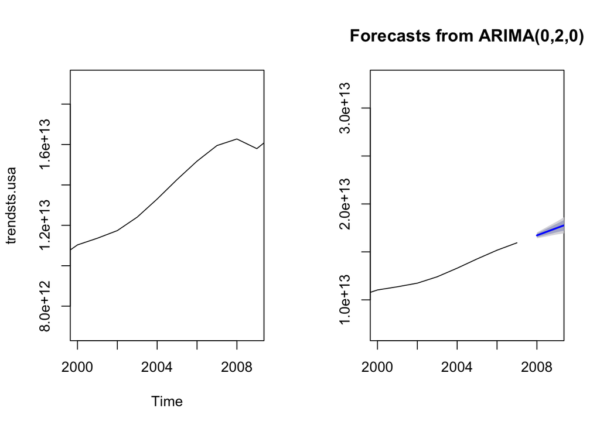

```r
trend.preds<-forecast.Arima(trends.arimausa,h=12)
plot.forecast(trend.preds, xlim = c(2000,2009))
```

```r
summary(trend.preds)
```

```
##
## Forecast method: ARIMA(0,2,0)
##
## Model Information:
## Series: trendsts.usabc
## ARIMA(0,2,0)
##
## sigma^2 estimated as 2.369e+22:  log likelihood=-407.68
## AIC=817.36   AICc=817.66   BIC=818.06
##
## Error measures:
##                       ME         RMSE          MAE       MPE      MAPE
## Training set 24655714785 144587829738 107823672936 0.2373676 0.9633879
##                   MASE       ACF1
## Training set 0.1882871 0.08904137
##
## Forecasts:
##      Point Forecast        Lo 80        Hi 80        Lo 95        Hi 95
## 2008    1.67203e+13 1.652304e+13 1.691756e+13 1.641861e+13 1.702199e+13
## 2009    1.74921e+13 1.705101e+13 1.793319e+13 1.681750e+13 1.816670e+13
## 2010    1.82639e+13 1.752581e+13 1.900199e+13 1.713509e+13 1.939271e+13
## 2011    1.90357e+13 1.795524e+13 2.011616e+13 1.738328e+13 2.068812e+13
## 2012    1.98075e+13 1.834455e+13 2.127045e+13 1.757012e+13 2.204488e+13
## 2013    2.05793e+13 1.869753e+13 2.246107e+13 1.770138e+13 2.345722e+13
## 2014    2.13511e+13 1.901705e+13 2.368515e+13 1.778147e+13 2.492073e+13
## 2015    2.21229e+13 1.930541e+13 2.494039e+13 1.781393e+13 2.643187e+13
## 2016    2.28947e+13 1.956451e+13 2.622489e+13 1.780161e+13 2.798779e+13
## 2017    2.36665e+13 1.979591e+13 2.753709e+13 1.774695e+13 2.958605e+13
## 2018    2.44383e+13 2.000097e+13 2.887563e+13 1.765199e+13 3.122461e+13
## 2019    2.52101e+13 2.018085e+13 3.023935e+13 1.751852e+13 3.290168e+13
```

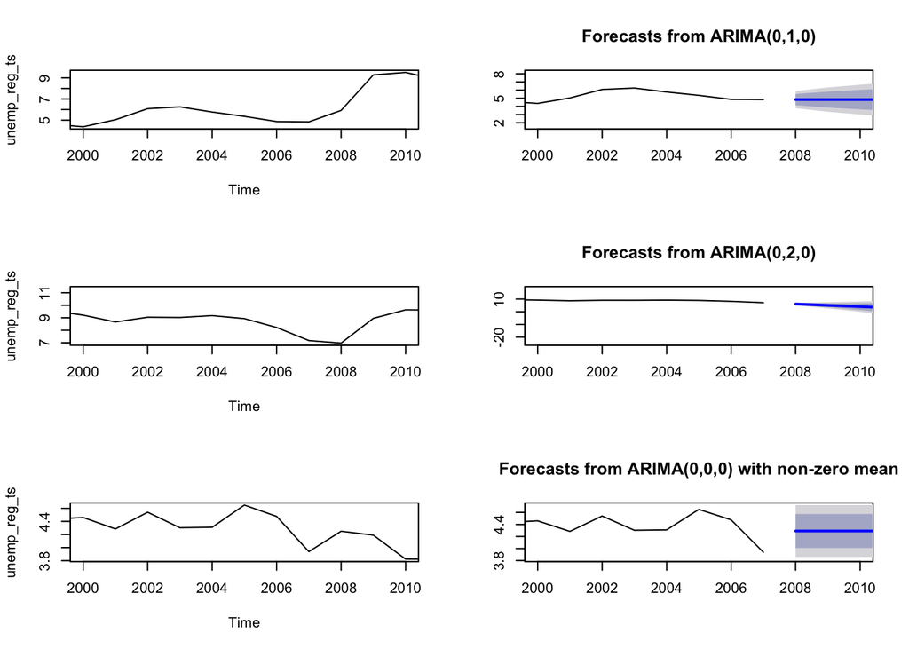

```r
par(mfrow=c(3,2))

#Subset data for NAC region from 1991 and 2014 and convert it to time series

Country_Code_Data <- c("NAC","EUU","SAS")

for(i in 1:length(Country_Code_Data))
{
unemp_reg <-region_data %>% select(Year,Unemployment.Rate,Country.Code) %>% filter(Country.Code == Country_Code_Data[i])
unemp_reg_ts <- ts(as.vector(unemp_reg$Unemployment.Rate),start = c(1991,1), end = c(2014), frequency = 1)

#Get data only until 2007 for NAC region and convert it to time series

unemp_reg_bc <- unemp_reg %>% filter(Year >=1991 & Year<=2007)
unemp_reg_bc_ts <- ts(as.vector(unemp_reg_bc$Unemployment.Rate),start = c(1991,1), end = c(2007), frequency = 1)

#Get data only until 2007 for NAC region and convert it to time series

unemp_reg_ac <- unemp_reg %>% filter(Year >=1991 & Year<=2008)
unemp_reg_ac_ts <- ts(as.vector(unemp_reg_ac$Unemployment.Rate),start = c(1991,1), end = c(2008), frequency = 1)

#Plotting US Trade data with all data

plot(unemp_reg_ts, xlim = c(2000,2010))

#Arima model for US Trade data only until crisis

mod_unemp_bc<- auto.arima(unemp_reg_bc_ts)
unemp_forecast_bc<-forecast.Arima(mod_unemp_bc)
plot.forecast(unemp_forecast_bc, xlim = c(2000,2010))

#Arima model for US Trade data after crisis until 2008

#mod_cpi_ac<- auto.arima(cpi_reg_ac_ts)
#cpi_forecast_ac<-forecast.Arima(mod_cpi_ac)
#plot.forecast(cpi_forecast_ac, xlim = c(2000,2010))

#Hypothesis testing for NAC Trade Arima Model

#Significance test for ARIMA model with data before
#coeftest(mod_unemp_bc)

#Significance test for ARIMA model with data after crisis until 2008
#coeftest(mod_cpi_ac)
}
```

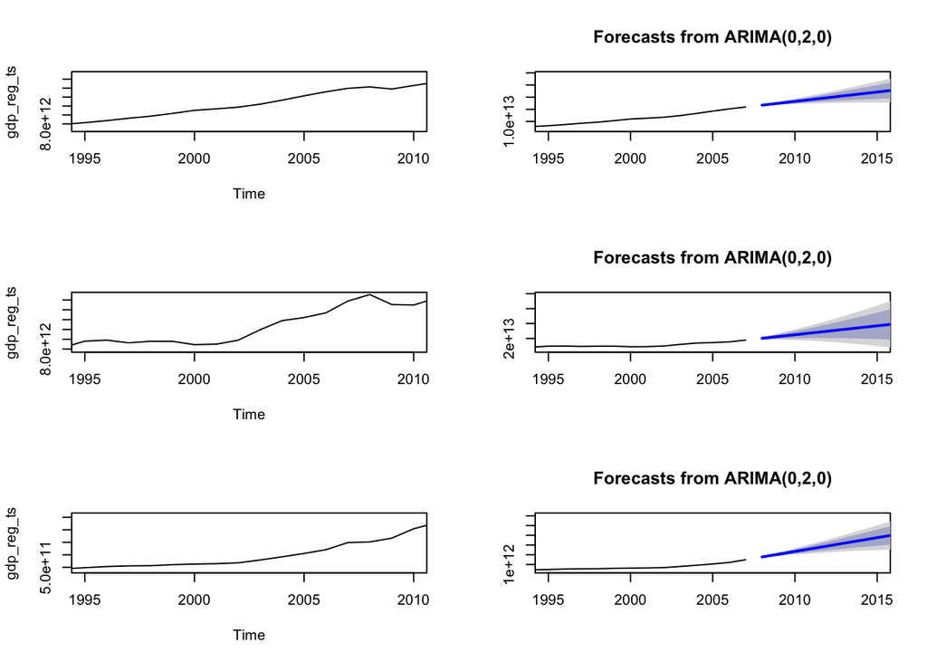

```r
par(mfrow=c(3,2))

#Subset data for NAC region from 1991 and 2014 and convert it to time series

Country_Code_Data <- c("NAC","EUU","SAS")

for(i in 1:length(Country_Code_Data))
{
gdp_reg <-region_data %>% select(Year,GDP,Country.Code) %>% filter(Country.Code == Country_Code_Data[i])
gdp_reg_ts <- ts(as.vector(gdp_reg$GDP),start = c(1991,1), end = c(2014), frequency = 1)

#Get data only until 2007 for NAC region and convert it to time series

gdp_reg_bc <- gdp_reg %>% filter(Year >=1991 & Year<=2007)
gdp_reg_bc_ts <- ts(as.vector(gdp_reg_bc$GDP),start = c(1991,1), end = c(2007), frequency = 1)

#Get data only until 2007 for NAC region and convert it to time series

gdp_reg_ac <- gdp_reg %>% filter(Year >=1991 & Year<=2008)
gdp_reg_ac_ts <- ts(as.vector(gdp_reg_ac$GDP),start = c(1991,1), end = c(2008), frequency = 1)

#Plotting US Trade data with all data


plot(gdp_reg_ts, xlim = c(1995,2010))

#Arima model for US Trade data only until crisis

mod_gdp_bc<- auto.arima(gdp_reg_bc_ts)
gdp_forecast_bc<-forecast.Arima(mod_gdp_bc)
plot.forecast(gdp_forecast_bc, xlim = c(1995,2015))

#Arima model for US Trade data after crisis until 2008

#mod_cpi_ac<- auto.arima(cpi_reg_ac_ts)
#cpi_forecast_ac<-forecast.Arima(mod_cpi_ac)
#plot.forecast(cpi_forecast_ac, xlim = c(2000,2010))

#Hypothesis testing for NAC Trade Arima Model

#Significance test for ARIMA model with data before
#coeftest(mod_gdp_bc)

#Significance test for ARIMA model with data after crisis until 2008
#coeftest(mod_gdp_ac)
}
```

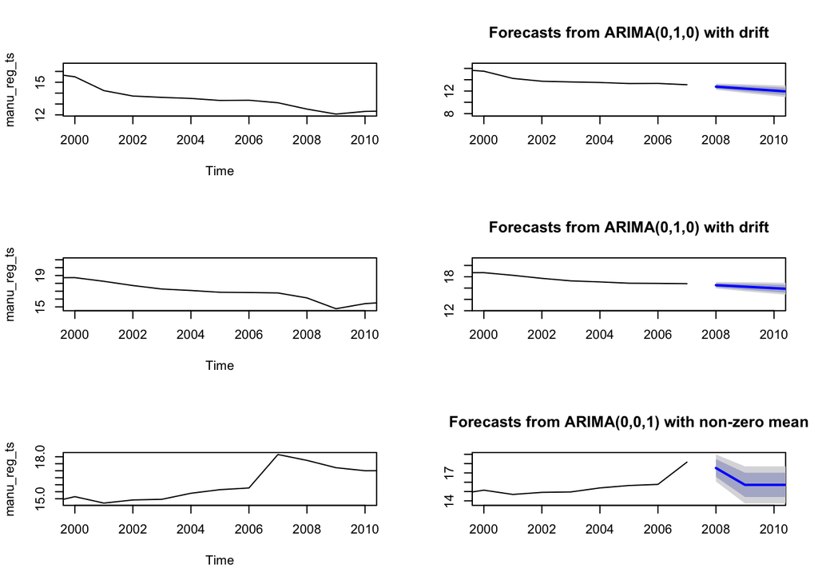

```r
par(mfrow=c(3,2))

#Subset data for NAC region from 1991 and 2014 and convert it to time series

Country_Code_Data <- c("NAC","EUU","SAS")

for(i in 1:length(Country_Code_Data))
{
manu_reg <-region_data %>% select(Year,Manufacturing.Rate,Country.Code) %>% filter(Country.Code == Country_Code_Data[i])
manu_reg_ts <- ts(as.vector(manu_reg$Manufacturing.Rate),start = c(1991,1), end = c(2014), frequency = 1)

#Get data only until 2007 for NAC region and convert it to time series

manu_reg_bc <- manu_reg %>% filter(Year >=1991 & Year<=2007)
manu_reg_bc_ts <- ts(as.vector(manu_reg_bc$Manufacturing.Rate),start = c(1991,1), end = c(2007), frequency = 1)

#Get data only until 2007 for NAC region and convert it to time series

manu_reg_ac <- manu_reg %>% filter(Year >=1991 & Year<=2008)
manu_reg_ac_ts <- ts(as.vector(manu_reg_ac$Manufacturing.Rate),start = c(1991,1), end = c(2008), frequency = 1)

#Plotting US Trade data with all data

plot(manu_reg_ts, xlim = c(2000,2010))

#Arima model for US Trade data only until crisis

mod_manu_bc<- auto.arima(manu_reg_bc_ts)
manu_forecast_bc<-forecast.Arima(mod_manu_bc)
plot.forecast(manu_forecast_bc, xlim = c(2000,2010))

#Arima model for US Trade data after crisis until 2008

#mod_cpi_ac<- auto.arima(cpi_reg_ac_ts)
#cpi_forecast_ac<-forecast.Arima(mod_cpi_ac)
#plot.forecast(cpi_forecast_ac, xlim = c(2000,2010))

#Hypothesis testing for NAC Trade Arima Model

#Significance test for ARIMA model with data before
coeftest(mod_manu_bc)

#Significance test for ARIMA model with data after crisis until 2008
#coeftest(mod_cpi_ac)

}
```

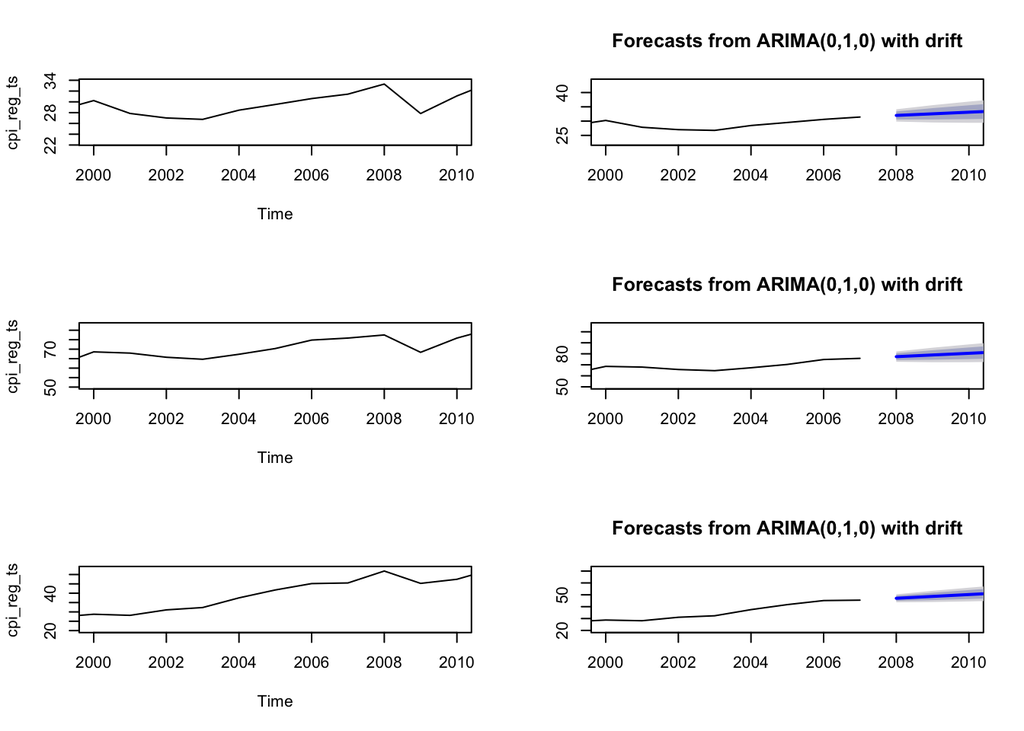

```r
par(mfrow=c(3,2))

#Subset data for NAC region from 1991 and 2014 and convert it to time series

Country_Code_Data <- c("NAC","EUU","SAS")

for(i in 1:length(Country_Code_Data))
{
cpi_reg <-region_data %>% select(Year,Trade,Country.Code) %>% filter(Country.Code == Country_Code_Data[i])
cpi_reg_ts <- ts(as.vector(cpi_reg$Trade),start = c(1991,1), end = c(2014), frequency = 1)

#Get data only until 2007 for NAC region and convert it to time series

cpi_reg_bc <- cpi_reg %>% filter(Year >=1991 & Year<=2007)
cpi_reg_bc_ts <- ts(as.vector(cpi_reg_bc$Trade),start = c(1991,1), end = c(2007), frequency = 1)

#Get data only until 2007 for NAC region and convert it to time series

cpi_reg_ac <- cpi_reg %>% filter(Year >=1991 & Year<=2008)
cpi_reg_ac_ts <- ts(as.vector(cpi_reg_ac$Trade),start = c(1991,1), end = c(2008), frequency = 1)

#Plotting US Trade data with all data

plot(cpi_reg_ts, xlim = c(2000,2010))

#Arima model for US Trade data only until crisis

mod_cpi_bc<- auto.arima(cpi_reg_bc_ts)
cpi_forecast_bc<-forecast.Arima(mod_cpi_bc)
plot.forecast(cpi_forecast_bc, xlim = c(2000,2010))

#Arima model for US Trade data after crisis until 2008

#mod_cpi_ac<- auto.arima(cpi_reg_ac_ts)
#cpi_forecast_ac<-forecast.Arima(mod_cpi_ac)
#plot.forecast(cpi_forecast_ac, xlim = c(2000,2010))

#Hypothesis testing for NAC Trade Arima Model

#Significance test for ARIMA model with data before
coeftest(mod_cpi_bc)

#Significance test for ARIMA model with data after crisis until 2008
#coeftest(mod_cpi_ac)

}
```

```r
CPI_trend<-read.csv("CPI_World_Bank.csv")
#plot(CPI_trend$)
colnames(CPI_trend)
```

```
##  [1] "Country.Name"   "Country.Code"   "Indicator.Name" "Indicator.Code"
##  [5] "X1960"          "X1961"          "X1962"          "X1963"
##  [9] "X1964"          "X1965"          "X1966"          "X1967"
## [13] "X1968"          "X1969"          "X1970"          "X1971"
## [17] "X1972"          "X1973"          "X1974"          "X1975"
## [21] "X1976"          "X1977"          "X1978"          "X1979"
## [25] "X1980"          "X1981"          "X1982"          "X1983"
## [29] "X1984"          "X1985"          "X1986"          "X1987"
## [33] "X1988"          "X1989"          "X1990"          "X1991"
## [37] "X1992"          "X1993"          "X1994"          "X1995"
## [41] "X1996"          "X1997"          "X1998"          "X1999"
## [45] "X2000"          "X2001"          "X2002"          "X2003"
## [49] "X2004"          "X2005"          "X2006"          "X2007"
## [53] "X2008"          "X2009"          "X2010"          "X2011"
## [57] "X2012"          "X2013"          "X2014"          "X2015"
## [61] "X2016"
```

```r
#goal here is time period on x and CPI on y.
trends<-read.csv("Timeseries.csv")
class(trends)
```

```
## [1] "data.frame"
```

```r
#summary(lm(Time ~ CPI_USA, data=trends))
#plot(trends)
#abline(lsfit(x=trends$Time,y=trends$CPI_USA),col="red")
#install.packages('tseries')
require(tseries)
#install.packages('xts')
require(xts)
#converting data into time series data
trends.ts<-ts(as.vector(trends), start = c(1960,1), end = c(2015),frequency = 1)
trends.ts
```

```
## Time Series:
## Start = 1960
## End = 2015
## Frequency = 1
##         CPI_USA
##  [1,]  13.57217
##  [2,]  13.71809
##  [3,]  13.87120
##  [4,]  14.03961
##  [5,]  14.22333
##  [6,]  14.46064
##  [7,]  14.89316
##  [8,]  15.30654
##  [9,]  15.95213
## [10,]  16.81589
```

[output cut: 46 more lines]

```r
class(trends.ts)
```

```
## [1] "ts"
```

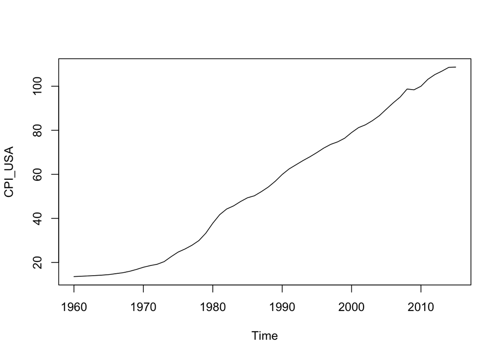

```r
plot(trends.ts)
```

```r
#Dickey-fuller test to see if the time series is stationary.
adf.test(trends.ts)
```

```
##
##  Augmented Dickey-Fuller Test
##
## data:  trends.ts
## Dickey-Fuller = -3.2846, Lag order = 3, p-value = 0.08307
## alternative hypothesis: stationary
```

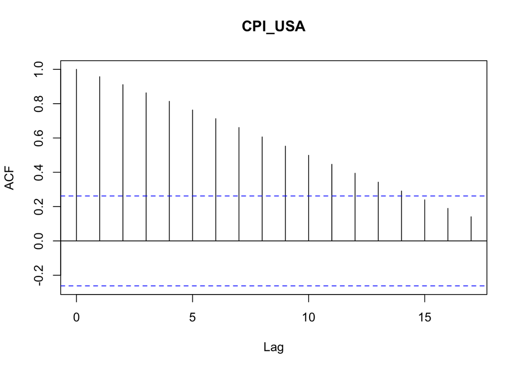

```r
#Checking for p and q values through auto correlation function and partial auto correlation function.
acf(trends.ts)
```

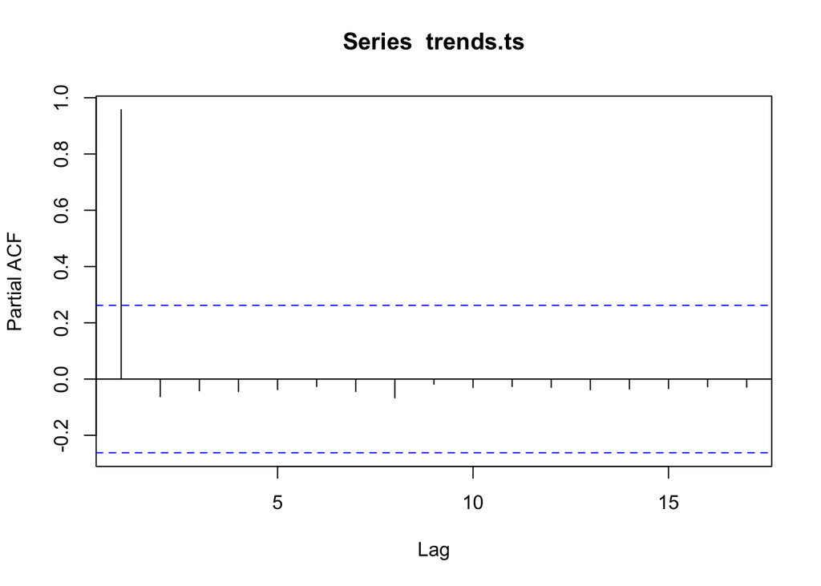

```r
pacf(trends.ts)
```

```r
#this is an AR model
auto.arima(trends.ts)
```

```
## Series: trends.ts
## ARIMA(1,2,1)
##
## Coefficients:
##          ar1      ma1
##       0.4603  -0.8296
## s.e.  0.2091   0.1391
##
## sigma^2 estimated as 0.7067:  log likelihood=-66.45
## AIC=138.9   AICc=139.38   BIC=144.87
```

```r
trends.arimausa<- arima(trends.ts, order=c(1,2,1))
trends.arimausa
```

```
##
## Call:
## arima(x = trends.ts, order = c(1, 2, 1))
##
## Coefficients:
##          ar1      ma1
##       0.4603  -0.8296
## s.e.  0.2091   0.1391
##
## sigma^2 estimated as 0.6805:  log likelihood = -66.45,  aic = 138.9
```

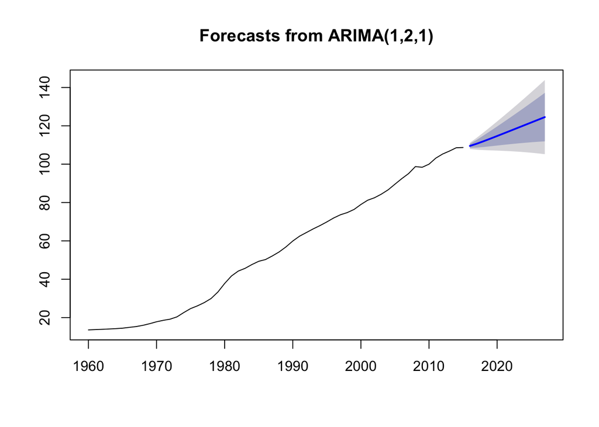

```r
trend.preds<-forecast.Arima(trends.arimausa,h=12)
plot.forecast(trend.preds)
```

```r
summary(trend.preds)
```

```
##
## Forecast method: ARIMA(1,2,1)
##
## Model Information:
##
## Call:
## arima(x = trends.ts, order = c(1, 2, 1))
##
## Coefficients:
##          ar1      ma1
##       0.4603  -0.8296
## s.e.  0.2091   0.1391
##
## sigma^2 estimated as 0.6805:  log likelihood = -66.45,  aic = 138.9
##
## Error measures:
##                      ME     RMSE       MAE       MPE     MAPE      MASE
## Training set 0.06899142 0.810064 0.5382748 0.4357933 1.112776 0.3089477
##                    ACF1
## Training set 0.02865192
##
## Forecasts:
##      Point Forecast    Lo 80    Hi 80    Lo 95    Hi 95
## 2016       109.5173 108.4601 110.5745 107.9005 111.1341
## 2017       110.6577 108.6354 112.6801 107.5648 113.7506
## 2018       111.9450 108.9485 114.9415 107.3623 116.5278
## 2019       113.2999 109.3225 117.2773 107.2169 119.3828
## 2020       114.6859 109.7148 119.6569 107.0833 122.2884
## 2021       116.0861 110.1025 122.0698 106.9349 125.2374
## 2022       117.4930 110.4728 124.5132 106.7566 128.2295
## 2023       118.9030 110.8190 126.9869 106.5396 131.2663
## 2024       120.3143 111.1373 129.4913 106.2793 134.3493
## 2025       121.7262 111.4257 132.0268 105.9729 137.4796
## 2026       123.1385 111.6832 134.5938 105.6191 140.6579
## 2027       124.5509 111.9094 137.1924 105.2174 143.8844
```

```r
#Hypothesis testing for USA CPI data
coeftest(trends.arimausa)
```

```
##
## z test of coefficients:
##
##     Estimate Std. Error z value  Pr(>|z|)
## ar1  0.46035    0.20911  2.2014   0.02771 *
## ma1 -0.82959    0.13908 -5.9649 2.447e-09 ***
## ---
## Signif. codes:  0 '***' 0.001 '**' 0.01 '*' 0.05 '.' 0.1 ' ' 1
```

```r
#z value is 2.2014, p=0.02771
#another way to obtain p value to verify
(1-pnorm(abs(trends.arimausa$coef)/sqrt(diag(trends.arimausa$var.coef))))*2
```

```
##          ar1          ma1
## 2.770520e-02 2.447359e-09
```

```r
trends.resid <- residuals(trends.arimausa)
Box.test(trends.resid, lag = 10, type = "Ljung-Box")
```

```
##
##  Box-Ljung test
##
## data:  trends.resid
## X-squared = 5.491, df = 10, p-value = 0.8561
```

Attempt to find trends in the CPI data. This data set contains CPI for 265 countries over a period of 56 years. The variable CPI is time sensitive. We have used Dickey-fuller test to see if the time series is stationary and checked for p and q values through auto correlation function and partial auto correlation function.

Provide a bullet-list of the next 5-10 tasks you will perform in analyzing your dataset

1. Compare the time series prediction with the actual data and see how well did the prediction work by checking statistical significance.
2. Improve the time series analysis across all the predictors and see how to convert our dataframe into timeseries for easier analysis.
3. Add more predictors to the dataset and analyze correlation. For example, we could add mental health to see the effects of the crisis on these predictors. We need to check feasibility of obtaining and merging such data into our analysis.
4. Quantify the propagation of the shock to the predictors due to the 2007 crisis using autocorrelation or other techniques.
5. Visualize the change in predictors on a map using geospatial plotting tools.